# MSCA 37010 Programming for Analytics

Copyright © Danny Ng

November 30, 2020

# 1 Lecture 1

## 1.1 Floating Point

- The default data type for representing and storing numbers in R is the `numeric` or `double` type.

```r
str(1)

x <- numeric(5) # Or double(5)
str(x)
```

```
 num 1
 num [1:5] 0 0 0 0 0
```

- Why is it called “double”? It refers to the [double-precision](https://en.wikipedia.org/wiki/Double-precision_floating-point_format) [binary](https://en.wikipedia.org/wiki/Binary_number) [floating-point](https://en.wikipedia.org/wiki/Floating_point) representation of a number in computer memory.
  - Scientific notation e.g. $1.2345 = 12345\times 10^{-4}$ with significand $12345$, base $10$, and exponent $-4$.
  - Use 64 bits to represent a number in base 2: 52 bits for the significand (about 16 digits of accuracy), 11 bits for the exponent, and 1 bit for the sign.
  - A [bit](https://en.wikipedia.org/wiki/Bit) is a single binary value of either 0 or 1.
  - The smallest and largest positive numbers are approximately $2^{-1022} \approx 10^{-308}$ and $2^{1023} \approx 10^{308}$.
  - [Double-precision](https://en.wikipedia.org/wiki/Double-precision_floating-point_format) uses 64 bits as opposed to [single-precision](https://en.wikipedia.org/wiki/Single-precision_floating-point_format) which uses 32 bits.
- Why is it called “floating”? For example, $1.2345 = 12345\times 10^{-4}$ and $123.45 = 12345\times 10^{-2}$ have the same significand but the decimal point floats around depending on the exponent.

```r
10^100
1e100
```

```
[1] 1e+100
[1] 1e+100
```

## 1.2 Numerical Inaccuracy

- Due to the limit of only 64 bits of memory to store a number, a stored value might not be exact.
- For example, in order to keep track of the large exponent, it might forget about the smaller digit positions.

```r
10^100 + 1 == 10^100
```

```
[1] TRUE
```

- For example, mathematical calculation might not be exact. It is up to a machine precision error `.Machine$double.eps` which depends on your 32-bit or 64-bit operating system.

```r
1 / 3 * 3 / 5 == 1 / 5
(1 / 3) * (3 / 5) == 1 / 5
.Machine$double.eps # Machine precision of R
```

```
[1] TRUE
[1] FALSE
[1] 2.220446e-16
```

```r
1 / 3 # Has more decimals internally than the displayed number 0.3333333
```

```
[1] 0.3333333
```

- Always compare two floating-point numbers for equality up to some small tolerance only.

```r
(1 / 3) * (3 / 5) -  1 / 5
abs((1 / 3) * (3 / 5) -  1 / 5) < 1e-10 # A tolerance of 1e-10 usually works.
```

```
[1] -2.775558e-17
[1] TRUE
```

**Exercise:** Find the value of `k` such that the following expresion is `TRUE`.

```r
10^k < Inf && 10^(k+1) == Inf
```

**Solution:** The answer is `k <- 308`. This illustrates that $10^{308}$ is about as large a number R can handle before R declares it as `Inf`.

**Exercise:** Give an example of a value `x` such that the following mathematically impossible expresion is `TRUE`.

```r
x != 0 && 1 + x == 1
```

**Solution:** An answer is `x <- 1e-16`. The value of `x` needs to be small enough so that when `1 + x` is being evaluated, in order for R to keep track of the unit digit of $1$, it fails to keep track of that tiny decimal of `x` and hence discards it.

## 1.3 Special Values

- `Inf` and `-Inf` denote positive and negative numbers that are too large to be represented by the usual `double`.

```r
1e500
1 / 0
```

```
[1] Inf
[1] Inf
```

- `NaN` is an abbreviation of “[not a number](https://en.wikipedia.org/wiki/NaN)”. It represents the result of an ill-defined mathematical calculation.

```r
Inf - Inf
Inf * 0
0 / 0 + 1 # Once you have an NaN, it propagates and stays as NaN.
```

```
[1] NaN
[1] NaN
[1] NaN
```

- `NA` is a special value in R to represent a missing value. It is often encountered when importing a data spreadsheet with some empty cells.

```r
student <- list(name="Bob", grade=NA)
```

```r
length(NA)
```

```
[1] 1
```

- `NULL` is a reserved keyword in R to represent the null object in R.

```r
length(NULL)
```

```
[1] 0
```

## 1.4 Boolean Logic

- Comparison: `==`, `>`, `<`, `!=`, `<=`, `>=`

```r
1 < 2
```

```
[1] TRUE
```

- Boolean operators: `!` NOT, `&&` AND, `||` OR
- [Truth tables](https://en.wikipedia.org/wiki/Truth_table)

```r
!TRUE
!FALSE
TRUE && FALSE # TRUE if both are TRUE
TRUE || FALSE # TRUE if at least one is TRUE
```

```
[1] FALSE
[1] TRUE
[1] FALSE
[1] TRUE
```

```r
(5 >= 4) && (1 != 2)
```

```
[1] TRUE
```

**Exercise:** Write an expression that evaluates to `TRUE` if and only if a given number $x$ is a natural number. (Hint: A number `x` is an integer if and only if the expression `x %% 1` equals `0`.)

**Solution:**

```r
(x > 0) && (x %% 1 == 0)
```

- The `&&` AND and `||` OR operators have [short-circuit](https://en.wikipedia.org/wiki/Short-circuit_evaluation) behavior i.e. R stops evaluating the rest of the expression once it knows the answer.

```r
FALSE && whatever
TRUE || whatever
```

- [Operator precedence](https://en.wikipedia.org/wiki/Order_of_operations) `?Syntax`  
  The `!` NOT operator is evaluted first, followed by the `&&` AND operator, and the `||` OR operator is last. If you are not sure, then use parentheses `(` and `)` explicitly.

```r
TRUE || TRUE && !TRUE # Same as TRUE || (TRUE && (!TRUE))
(TRUE || TRUE) && (!TRUE)
```

```
[1] TRUE
[1] FALSE
```

```r
1:5 + 2 # Which of the + and : operators has precedence?
(1:5) + 2
1:(5 + 2)
```

```
[1] 3 4 5 6 7
[1] 3 4 5 6 7
[1] 1 2 3 4 5 6 7
```

**Exercise:** Without executing the code, can you tell what value each of the following expressions is? Explain why.

```r
2 ** 3 ** 4
TRUE || TRUE && TRUE && FALSE
1 -- 1 == 1 ++ 1
```

**Solution:**

1. The exponent operator `**` is actually evaluated from right to left (in contrast to other arithmetic operators like `+` or `-`). So the expression is equivalent to `2 ** (3 ** 4)`.
2. The expression is equivalent to `TRUE || ((TRUE && TRUE) && FALSE)`.
3. Despite the misleading placement of the spaces, the expression is actually equivalent to `(1 - (-1)) == (1 + (+1))`.
- Built-in functions for logical vector: `all()`, `any()`, `which()`

```r
x <- c(TRUE, FALSE, FALSE, TRUE)
all(x)
any(x)
which(x) # Indices of TRUE values
```

```
[1] FALSE
[1] TRUE
[1] 1 4
```

- Vectorized AND and OR: `&`, `|`

```r
x <- c(TRUE, TRUE, FALSE)
y <- c(TRUE, FALSE, FALSE)
x & y
x | y
```

```
[1]  TRUE FALSE FALSE
[1]  TRUE  TRUE FALSE
```

- Sometimes, an ordinary English description of a statement could be misleading and even logically wrong.

For example, the English statement “find all numbers in `x <- 1:10` that is smaller than 5 and larger than 7” should mean “all numbers that are smaller than 5 and all numbers that are greater than 7”. Here “and” represents the union of two sets. Therefore, we should use the OR operator programatically. In fact, it is more precise to write the original statement as “all numbers in `x` that is either smaller than 5 or larger than 7” because a number cannot be both smaller than 5 and also larger than 7 at the same time.

```r
x <- 1:10
x[x < 5 & x > 7]
x[x < 5 | x > 7]
```

```
integer(0)
[1]  1  2  3  4  8  9 10
```

## 1.5 IF Statement

- The lines of code in an R program are executed one after another sequentially. One way to change this workflow of the program is to use conditional statements i.e. IF ELSE statements.
- The main components of an IF statement are:
  1. `if`
  2. A logical expression inside `()`
  3. A block one or more lines of code inside `{}` to be executed

```r
x <- -2
if (x < 0) {
  x <- -x
  # Can have multiple lines of code here.
}
x
# Question: What is this program called?
```

```
[1] 2
```

- Draw a flow diagram.
- Spacing and indentation do not matter in R.

```r
if(x<0){x<- -x} # This works but is bad style.
```

- You can omit the curly brackets `{}` if the block of code consists of only one line.

```r
x <- -2
if (x < 0)
  x <- -x # This works but is bad style.
x
```

```
[1] 2
```

- The IF ELSE statement. Exactly one of the two code blocks will be executed.

```r
x <- 1
y <- 2
if (x < y) {
  answer <- y
} else {
  answer <- x
}
answer
# Question: What is this program called?
```

```
[1] 2
```

- Nesting of IF ELSE statements: Since an IF ELSE statement is considered as one statement, it can be nested inside a code block of another IF ELSE statement.

```r
x <- 2
if (x < 0) {
  answer <- -1
} else {
  if (x == 0) {
    answer <- 0
  } else { # If the program reaches here, then x must be positive.
    answer <- 1
  }
}
answer
# Question: What is this program called?
```

```
[1] 1
```

**Exercise:** Write an R script that takes a vector of $3$ numbers and returns their maximum value. Note that you should use IF statements but not any built-in R function e.g. `max()`.

For example,

```r
x <- c(3, 7, -2)
# ... Skipped code ...
answer
```

```
[1] 7
```

**Solution:**

```r
x <- c(3, 7, -2)
if (x[1] > x[2]) {
  if (x[1] > x[3]) {
    answer <- x[1]
  } else {
    answer <- x[3]
  }
} else {
  if (x[2] > x[3]) {
    answer <- x[2]
  } else {
    answer <- x[3]
  }
}
answer
```

```
[1] 7
```

- The nested structure above is so common that R provides an IF ELSEIF ELSE statement for it. Exactly one of the three code blocks will be executed.

```r
x <- 2
if (x < 0) {
  answer <- -1
} else if (x == 0) { # It is "else if", not "elseif" or "elif".
  answer <- 0
} else { # If the program reaches here, then x must be positive.
  answer <- 1
}
answer
```

```
[1] 1
```

- You can have multiple ELSEIF statements. Moreover, the ELSE statement is always optional.

```r
x <- 36
if (x %% 2 == 0 && x %% 3 == 0) {
  print("This x is divisible by 2 and 3.")
} else if (x %% 2 == 0) {
  print("This x is divisible by 2 but not 3.")
} else if (x %% 3 == 0) {
  print("This x is divisible by 3 but not 2.")
}
```

```
[1] "This x is divisible by 2 and 3."
```

- The ordering of the IF, ELSE IF, and ELSE conditions matters. In some cases, if you swap them around, you might get a completely different program logic.
- Built-in function: `ifelse()`

```r
x <- c(1, -2, -3, 4, 5)
answer <- ifelse(x %% 2 == 0, "even", "odd") # Vectorize
answer
```

```
[1] "odd"  "even" "odd"  "even" "odd"
```

**Exercise:** Write a program to check if a number $x$ is a perfect square i.e. if there exists an integer $y$ such that $y^2 = x$. (Hint: A number `y` is an integer if the expression `y %% 1` equals `0`.)

```r
x <- 121
# ... Skipped code ...
answer
```

**Solution:**

```r
x <- 121
if (x < 0) {
  answer <- FALSE
} else {
  # Now x is a non-negative number.
  y <- sqrt(x)
  if (y %% 1 == 0) {
    answer <- TRUE
  } else {
    answer <- FALSE
  }
}
answer
```

Can we simplify the program? Yes. Notice that the inner IF ELSE statement assigns the `TRUE` value to `answer` exactly when the condition `y %% 1 == 0` is `TRUE`.

```r
x <- 121
if (x < 0) {
  answer <- FALSE
} else {
  # Now x is a non-negative integer.
  y <- sqrt(x)
  answer <- y %% 1 == 0 # The IF statement above is logically equivalent to this.
}
answer
```

Can we simplify the program more? Yes.

```r
x <- 121
answer <- x > 0 && sqrt(x) %% 1 == 0
```

Notice that we depend the [short-circuit](https://en.wikipedia.org/wiki/Short-circuit_evaluation) behavior of the AND operator `&&`. So `sqrt(x)` would not be evaluated (and complain with error) unless `x` is positive.

## 1.6 Homework

1. Without executing the code, can you tell what the value of `answer` is? Now execute the code. What is the value of `answer`? Explain why. In particular, it does not compute the average of the positive numbers in `x`. Write code to compute it.

```r
x <- c(0.07, -0.42, 0.48, -0.14, 0.20, -0.44, 0.27, 0.05)
answer <- mean(x > 0)
answer
```

**Solution:** The logical values of `TRUE` and `FALSE` are converted to `1` and `0` implicitly before R computes a sample average using the built-in `mean()` function. This is a convenient trick to calculate the fraction of `TRUE` values of a logical vector e.g. error rate in a binary classification task.

```r
positive.avg <- mean(x[x > 0])
```

2. Execute the following code and understand what is going on.

```r
x <- 1:10
x
dim(x) <- c(2, 5)
x
dim(x) <- c(5, 2)
x
dim(x) <- NULL
x
```

**Solution:** The code illustrates the point that a matrix is in fact just a vector with additional attribute about its dimensions via `dim()`. Once the information about its dimensions is erased by setting its `dim()` to `NULL`, R treats `x` as a vector again.

3. Write an R script that takes a number `score` between $0$ and $100$ and stores the corresponding letter grade in the `letter.grade` variable according to the following table

| Score | Letter Grade |
| --- | --- |
| 90 - 100 | A |
| 80 - 89 | B |
| 70 - 79 | C |
| 60 - 69 | D |
| 50 - 59 | E |
| 0 - 49 | F |

For example,

```r
score <- 83
# ... Skipped code ...
letter.grade
```

```
[1] "B"
```

You should organize your ELSE IF statements appropriately to avoid using the `&&` AND operator. Use comparisons but not any mathematical calculation. Do not use any R’s built-in function such as `%in%` or `is.element()`.

**Solution:**

```r
score <- 83
if (score >= 90) {
  letter.grade <- "A"
} else if (score >= 80) {
  letter.grade <- "B"
} else if (score >= 70) {
  letter.grade <- "C"
} else if (score >= 60) {
  letter.grade <- "D"
} else if (score >= 50) {
  letter.grade <- "E"
} else {
  letter.grade <- "F"
}
letter.grade
```

```
[1] "B"
```

4. Write an R script that takes a vector `x` of 3 numbers and stores the 3 numbers in ascending order in the `answer` variable. Note that you should only use IF statements and comparisons but not any built-in R function e.g. `min()`, `max()`, `sort()`, `order()`, `rank()`. (Hint: Test your code with various values of `x` to ensure it works correctly in all cases.)

```r
x <- c(3, 7, -2)
# ... Skipped code ...
answer
```

```
[1] -2  3  7
```

**Solution:**

```r
if (x[1] > x[2]) {
  if (x[1] > x[3]) {
    if (x[2] < x[3]) {
      answer <- x[c(2, 3, 1)]
    } else {
      answer <- x[c(3, 2, 1)]
    }
  } else {
    answer <- x[c(2, 1, 3)]
  }
} else {
  if (x[2] > x[3]) {
    if (x[1] < x[3]) {
      answer <- x[c(1, 3, 2)]
    } else {
      answer <- x[c(3, 1, 2)]
    }
  } else {
    answer <- x[c(1, 2, 3)]
  }
}
answer
```

# 2 Lecture 2

## 2.1 Memory Management: Vector vs List

- A simplified (and not entirely accurate) description of computer memory with R.
- Atomic data type: Each object has a name, a data type (and hence an object size), a [memory address](https://en.wikipedia.org/wiki/Memory_address), and a data value.

```r
x <- 1.23 # A variable of double type occupies 64 bits of memory.
```

- A vector or matrix occupies a consecutive block of memory.
  - Integer indexing is calculated using memory address offset.
  - This is the reason why they can only store data of the same type.
  - The longest vector or largest matrix you can create depends on the largest consecutive block of memory that R can allocate.

```r
x <- seq(0, 1, length.out=10) # Occupy a consecutive block of 640 bits of memory.
```

- A list is a sequence of memory addresses. Each memory address refers to (i.e. points to) the block of memory that stores the actual data.

```r
x <- list(1, "two", matrix(3, 3, 3)) # Occupy 3 separate memory locations.
```

- What happen when you assign a new value to an existing variable? [Immutable object](https://en.wikipedia.org/wiki/Immutable_object) and modification in-place.

```r
x <- c(1, 2, 3)
x <- c(4, 5, 6) # Another memory location is used to store the new object.
```

```r
x <- c(1, 2, 3)
x[1] <- 4 # The value at the particular memory location is modified in-place.
```

```r
x <- list(matrix(2, 2, 2), matrix(3, 3, 3))
x[1] <- "two" # The memory address points to a new memory location.
```

- What happen when you append additional data to an existing vector (or matrix) or list?

```r
x <- 1
x <- c(x, 2) # Allocate a new block of memory for the entire vector everytime.  It is slow.
x <- c(x, 3)
```

```r
x <- list(matrix(2, 2, 2), matrix(3, 3, 3))
x[[3]] <- matrix(4, 4, 4) # Only allocate additional memory for the new data.
```

- The importance of pre-allocation of memory instead of growing a variable.

```r
x <- numeric(3) # Pre-allocation of the entire vector first.
x[1] <- 1       # Modify in-place.
x[2] <- 2
x[3] <- 3
```

- What happen when your new variable comes from (perhaps part of) an existing variable? A simplified story: it is always a [deep copy](https://en.wikipedia.org/wiki/Object_copying#Deep_copy). So you do not need to worry about the variables affect each other. This behavior might not be true for other programming languages (such as Python).

```r
x <- 1
y <- x # A new block of memory is created for a copy of x.
x <- 2
x
y
```

```
[1] 2
[1] 1
```

```r
x <- 1:5
y <- x[2:4] # A copy.
x[3] <- 6
x
y
```

```
[1] 1 2 6 4 5
[1] 2 3 4
```

```r
x <- list(list(a=1), list(b=2))
y <- x[[1]] # It is a (deep) copy no matter how nested it is.
y$a <- 10
x
y
```

```
[[1]]
[[1]]$a
[1] 1


[[2]]
[[2]]$b
[1] 2


$a
[1] 10
```

- What really happen when your new variable comes from (perhaps part of) an existing variable? The simplified truth: R is smart and uses [lazy evaluation](https://en.wikipedia.org/wiki/Lazy_evaluation). Since the copying of data can be costly in terms of both time and memory, R keeps track of the relationships among the variables and defers the copying operation until it is necessary.

```r
x <- 1:3
y <- x     # Both x and y share the same block of memory until they cannot.
y[1] <- 10 # Now y finally refers to a new block of memory.
```

- What happen to the used memory? Memory fragmentation, automatic garbage collection and `gc()`, and [memory leak](https://en.wikipedia.org/wiki/Memory_leak).

## 2.2 FOR Loop

- Use a loop when you want to repeat some part of a program multiple times.

```r
print(1)
print(2)
print(3)

x <- c(0.28, 1.3, -1.14)
total <- 0
total <- total + x[1]
total <- total + x[2]
total <- total + x[3]
total
```

```
[1] 1
[1] 2
[1] 3
[1] 0.44
```

- Modern programming languages such as R and Python support both the [FOR loop](https://en.wikipedia.org/wiki/For_loop) and the [WHILE loop](https://en.wikipedia.org/wiki/While_loop) statements.
  - Use a FOR loop to iterate over a sequence of data.
  - Use a WHILE loop to repeat something until some stay condition becomes `FALSE`.
- The main components of a FOR Loop are:
  1. `for`
  2. A sequence of data inside `()`
  3. A variable that stores the current iteration of data
  4. `in`
  5. A block of one or more lines of code inside `{}` to be executed
- Explain the workflow of the FOR loop in more details.

```r
for (i in 1:3) {
  print(i)
}

x <- c(0.28, 1.3, -1.14)
total <- 0
for (i in 1:length(x)) {
  total <- total + x[i]
}
total
```

```
[1] 1
[1] 2
[1] 3
[1] 0.44
```

- Similar to an IF statement, spacing and indentation do no matter.
- You can omit the curly brackets `{}` if the block of code consists of only one line.

**Exercise:** Write a FOR loop to mimic the built-in R function `diff()` of the vector `x`.

```r
x <- c(1, 7, -2, 0, 5)
# ... Skipped code ...
answer
```

**Solution:**

```r
x <- c(1, 7, -2, 0, 5)

n <- length(x)
answer <- numeric(n - 1) # Initialize first.
for (i in 1:(n-1)) {
  answer[i] <- x[i+1] - x[i]
}
answer
```

```
[1]  6 -9  2  5
```

**Exercise:** Write a FOR loop to mimic the built-in R function `cumsum()` of the vector `x`.

```r
x <- c(1, 7, -2, 0, 5)
# ... Skipped code ...
answer
```

**Solution:**

```r
x <- c(1, 7, -2, 0, 5)

n <- length(x)
answer <- numeric(n) # Initialize first.
answer[1] <- x[1]
for (i in 2:n) {
  answer[i] <- answer[i-1] + x[i]
}
answer
```

```
[1]  1  8  6  6 11
```

**Exercise:** Write a FOR loop to mimic the built-in R function `rev()` of the vector `x`. Can you do it in-place inside `x` without creating another vector called `answer`?

```r
x <- c(1, 7, -2, 0, 5)
# ... Skipped code ...
answer
```

**Solution:**

```r
x <- c(1, 7, -2, 0, 5)

n <- length(x)
answer <- numeric(n)
for (i in 1:n) {
  answer[i] <- x[n-(i-1)]
}
answer
```

```
[1]  5  0 -2  7  1
```

```r
x <- c(1, 7, -2, 0, 5)

n <- length(x)
k <- n %/% 2 # Index of the midpoint of the vector.
for (i in 1:k) {
  temp <- x[i] # Need a temporary variable.
  x[i] <- x[n-(i-1)]
  x[n-(i-1)] <- temp
}
x
```

```
[1]  5  0 -2  7  1
```

**Exercise:** Write a FOR loop to mimic the built-in R function `which.max()` of the vector `x`. What if we want the last index but not the first index of the largest value?

```r
x <- c(1, 7, -2, 7, 5)
# ... Skipped code ...
answer
```

**Solution:**

```r
x <- c(1, 7, -2, 7, 5)

answer <- 1
for (i in 1:length(x)) {
  if (x[i] > x[answer]) {
    answer <- i
  }
}
answer
```

```
[1] 2
```

```r
x <- c(1, 7, -2, 7, 5)

answer <- 1
for (i in 1:length(x)) {
  if (x[i] >= x[answer]) { # Just change > to >=
    answer <- i
  }
}
answer
```

```
[1] 4
```

**Exercise:** Write a FOR loop to mimic the built-in R function `pmin()` of two vectors `x` and `y` of the same length.

```r
x <- c(1, 7, -2, 7, 5)
y <- c(-3, 4, 6, 0, 9)
# ... Skipped code ...
answer
```

**Solution:**

```r
x <- c(1, 7, -2, 7, 5)
y <- c(-3, 4, 6, 0, 9)

n <- length(x)
answer <- numeric(n)
for (i in 1:n) {
  if (x[i] < y[i]) {
    answer[i] <- x[i]
  } else {
    answer[i] <- y[i]
  }
}
answer
```

```
[1] -3  4 -2  0  5
```

- The index variable:
  - Any valid variable name is OK
  - The variable can exist before the FOR loop.
  - The variable will continue to exist after the FOR loop
  - You can change the value of the index variable inside the FOR loop. It will be reset by R at the beginning of the next iteration.

```r
x <- 1
print(x)
for (x in 3:5) {
  print(x)
  x <- 10 # Bad style
  print(x)
}
print(x)
```

```
[1] 1
[1] 3
[1] 10
[1] 4
[1] 10
[1] 5
[1] 10
[1] 10
```

- The sequence of data inside `()` can be any sequence of data i.e. vector or list, and not just `1:n`.

```r
fruits <- c("apple", "banana", "orange", "kiwi")

total <- 0
for (i in 1:length(fruits)) { # Loop over an index
  print(i)
  total <- total + nchar(fruits[i])
}
total
```

```
[1] 1
[1] 2
[1] 3
[1] 4
[1] 21
```

```r
fruits <- c("apple", "banana", "orange", "kiwi")

total <- 0
for (fruit in fruits) { # Loop over the data
  print(fruit)
  total <- total + nchar(fruit)
}
total
# Question: What is the proper way of doing this in R?
```

```
[1] "apple"
[1] "banana"
[1] "orange"
[1] "kiwi"
[1] 21
```

```r
basket <- list(list(fruit="apple", price=1.99),
               list(fruit="banana", price=0.59),
               list(fruit="orange", price=1.29),
               list(fruit="kiwi", price=0.5))

total.price <- 0
for (item in basket) {
  print(item$fruit)
  total.price <- total.price + item$price
}
total.price
```

```
[1] "apple"
[1] "banana"
[1] "orange"
[1] "kiwi"
[1] 4.37
```

- The FOR loop itself does not allow you to iterate over two sequences simultaneously. So you need to improvise.

```r
fruits <- c("apple", "banana", "orange", "kiwi")

n <- length(fruits)
num.char <- numeric(n)
i <- 1 # Initialize an index.
for (fruit in fruits) {
  num.char[i] <- nchar(fruit)
  i <- i + 1 # Increment the index by ourselves.
}
num.char
```

```
[1] 5 6 6 4
```

- Nested loops i.e. a loop inside a loop

```r
m <- matrix(1:24, 4, 6)

answer <- 0
for (i in 1:nrow(m)) {
  for (j in 1:ncol(m)) {
    answer <- answer + m[i,j]
  }
}
answer
# Question: What is this program called?
```

```
[1] 300
```

- Contiguous memory allocation and [column-major ordering](https://en.wikipedia.org/wiki/Row-major_order) of matrix: It is more efficient to loop down each column than to loop across each row in R.

**Exercise:** Write a nested FOR loops to mimic the built-in R function `colMeans()` of the matrix `m`.

```r
m <- matrix(1:24, 4, 6)
# ... Skipped code ...
answer
```

**Solution:**

```r
m <- matrix(1:24, 4, 6)

num.row <- nrow(m)
num.col <- ncol(m)
answer <- numeric(num.col)
for (j in 1:num.col) {
  for (i in 1:num.row) {
    answer[j] <- answer[j] + m[i,j]
  }
  answer[j] <- answer[j] / num.row
}
answer
```

```
[1]  2.5  6.5 10.5 14.5 18.5 22.5
```

- Demonstrate how to trace a program.
- Use the `break` keyword to exit early from a FOR loop.

For example, here is how to implement the `any()` functionality.

```r
x <- c(FALSE, FALSE, TRUE, FALSE, FALSE)

answer <- FALSE # Use a flag.
for (value in x) {
  if (value) { # Same as checking if value == TRUE.
    answer <- TRUE # This is the only way to change the answer.
    break
  }
}
answer
```

```
[1] TRUE
```

**Exercise:** Write a FOR loop with `break` to mimic the built-in R function `all()` for the vector `x`.

```r
x <- c(TRUE, TRUE, TRUE, FALSE, TRUE)
# ... Skipped code ...
answer
```

**Solution:**

```r
x <- c(TRUE, TRUE, TRUE, FALSE, TRUE)

answer <- TRUE
for (value in x) {
  if (!value) { # Same as checking if value is FALSE.
    answer <- FALSE # This is the only way to change the answer.
    break
  }
}
answer
```

```
[1] FALSE
```

- Use the `next` keyword to skip the remaining of the code and continue with the next iteration of the FOR loop.
- For example, here are two different FOR loops that are logically equivalent. Using the `next` keyword might yield nicer-looking code because of less indentation.

```r
total <- 0
for (x in 1:100) {
  if (x %% 7 == 0) {
    total <- total + x
  }
}
total
```

```
[1] 735
```

```r
total <- 0
for (x in 1:100) {
  if (x %% 7 != 0) {
    next
  }
  total <- total + x
}
total
```

```
[1] 735
```

## 2.3 Homework

1. Write a nested FOR loops to obtain the upper triangular matrix of `m`. In other words, it sets all the elements of `m` that are below the diagonal to `0`. Do not use any IF statement or any R’s built-in function such as `lower.tri()`.

```r
d <- 6
m <- matrix(1:(d*d), d, d)
# ... Skipped code ...
m
```

```
     [,1] [,2] [,3] [,4] [,5] [,6]
[1,]    1    7   13   19   25   31
[2,]    0    8   14   20   26   32
[3,]    0    0   15   21   27   33
[4,]    0    0    0   22   28   34
[5,]    0    0    0    0   29   35
[6,]    0    0    0    0    0   36
```

**Solution:**

```r
d <- 6
m <- matrix(1:(d*d), d, d)
for (i in 2:d) {
  for (j in 1:(i-1)) {
    m[i,j] <- 0
  }
}
m
```

2. Write an R program that takes an atomic variable `v` and a vector `y`, and returns `TRUE` if `v` is an element of `y`, and `FALSE` otherwise. You should use the `break` keyword somehwere in your code. Do not use any R’s built-in function such as `is.element()` or `%in%`.

```r
v <- 0
y <- c(-1, 0, 1)
# ... Skipped code ...
answer
```

```
[1] TRUE
```

**Solution:**

```r
v <- 0
y <- c(-1, 0, 1)

answer <- FALSE
for (value in y) {
  if (v == value) {
    answer <- TRUE
    break
  }
}
answer
```

3. Write an R program to mimic the built-in R function `is.element(x, y)` of two vectors `x` and `y`. In other words, your program returns a vector `answer` of the same length as `x`, and `answer[i]` is `TRUE` if and only if `x[i]` is an element of `y`. Do not use any R’s built-in function such as `is.element()` or `%in%`. (Hint: Use the code from the previous question. Use `logical()` for initialization.)

```r
x <- c(3, 0, -2, 0)
y <- c(-1, 0, 1)
# ... Skipped code ...
answer
```

```
[1] FALSE  TRUE FALSE  TRUE
```

**Solution:**

```r
x <- c(3, 0, -2, 0)
y <- c(-1, 0, 1)

num.x <- length(x)
answer <- logical(num.x)
for (i in 1:num.x) { # If we loop through x directly, then we cannot use index i for answer[i].
  for (value in y) {
    if (x[i] == value) {
      answer[i] <- TRUE
      break
    }
  }
}
answer
```

# 3 Lecture 3

## 3.1 WHILE Loop

- Use a WHILE loop to repeat something until some stay condition becomes `FALSE`.
- Unlike a FOR loop, there is usually not a fixed sequence of data to iterate over. You just want to repeat some task until some exit condition is satisfied.
- The main components of a WHILE loop are:
  1. `while`
  2. A logical expression inside `()`
  3. A block of one or more lines of code inside `{}` to be executed
- Draw a flow diagram.

```r
x <- 5
while (x >= 0) {
  print(x)
  x <- x - 1
}
```

```
[1] 5
[1] 4
[1] 3
[1] 2
[1] 1
[1] 0
```

**Exercise:** Find the smallest integer $k$ such that $10^k$ is `Inf`. (Hint: Use the built-in R function `is.finite()`.)

**Solution:**

```r
k <- 0
while (is.finite(10 ^ k)) {
  k <- k + 1
}
k
```

```
[1] 309
```

- Unlike a FOR loop, sometimes you do not know a priori when the WHILE loop will exit and stop.

For example, the following R program generates a sequence of fair coin tosses until $n$ heads `"H"` are observed.

```r
n <- 5

# Initialize.
history <- c()
num.head <- 0

while (num.head < n) {
  coin <- sample(c("H", "T"), 1)
  history <- c(history, coin) # Bad to grow a vector in general
  if (coin == "H") {
    num.head <- num.head + 1
  }
}
history
```

```
[1] "H" "T" "H" "H" "T" "H" "H"
```

- The WHILE loop is more general than the FOR loop: Any FOR loop can be written as a logically equivalent WHILE loop.

```r
for (i in a:b) {
  # Do some work with i.
}
```

```r
i <- a
while (i <= b) {
  # Do some work with i
  i <- i + 1
}
```

**Exercise:** Write the logically equivalent WHILE loop for the following FOR loop.

```r
for (x in v) { # Here v is a vector or list.
  # Do some work with x.
}
```

**Solution:**

```r
n <- length(v)
i <- 1
while (i <= n) {
  x <- v[i]
  # Do some work with x.
  i <- i + 1
}
```

- The `break` and the `next` keywords can be used with a WHILE loop too.
- The `while (TRUE)` programming pattern and a seemingly infinite loop.

```r
while (TRUE) {
  # ... Some code ...
}
```

```r
while (TRUE) {
  # ... Some code ...
  if (exit) {
    break
  }
  # ... Some code ...
}
```

- When do we use the `while (TRUE)` programming pattern? To eliminate duplicate code if we need to execute some code once before checking the exit condition i.e. to minic the [Do WHILE loop](https://en.wikipedia.org/wiki/Do_while_loop) which is not available in R.

For example, the following R program generates a sequence of unfair coin tosses until a head `"H"` with probability $P(H) = 0.1$. Note the duplicate code just before the WHILE loop to generate the first coin toss before checking if it is a head or not.

```r
history <- c()

coin <- sample(c("H", "T"), 1, prob=c(0.1, 0.9)) # First coin toss.
history <- c(history, coin)
while (coin != "H") {
  coin <- sample(c("H", "T"), 1, prob=c(0.1, 0.9)) # Subsequent coin tosses.
  history <- c(history, coin)
}
history
```

```
 [1] "T" "T" "T" "T" "T" "T" "T" "T" "T" "T" "T" "T" "T" "T" "T" "T" "T" "T" "T"
[20] "T" "T" "T" "T" "T" "T" "T" "T" "H"
```

We wish to execute the code once first before checking the exit condition. In other words, we would like to essentially place the exit condition at the end of the WHILE loop instead of at the beginning.

```r
history <- c()

while (TRUE) {
  coin <- sample(c("H", "T"), 1, prob=c(0.1, 0.9))
  history <- c(history, coin)
  if (coin == "H") {
    break
  }
}
history
```

```
 [1] "T" "T" "T" "T" "T" "T" "T" "T" "T" "T" "T" "T" "T" "T" "T" "T" "T" "T" "T"
[20] "T" "T" "T" "T" "T" "T" "H"
```

**Exercise:** Write an R program to implement the [bisection root-finding method](https://en.wikipedia.org/wiki/Bisection_method) for the following continuous function `f`.

```r
f <- function(x) {
  x^3 - 3 * x^2 + 1
}

f(2)
f(4)
```

```
[1] -3
[1] 17
```

**Solution:**

```r
a <- 2
b <- 4

tolerance <- 1e-10
while (abs(a - b) > tolerance) { # Check exit condition.
  # Find midpoint.
  m <- (a + b) / 2
  # Is it exactly a root?
  if (f(m) == 0) {
    break
  }
  # Now shrink our interval [a,b] to either [m,b] or [a,m].
  if (sign(f(m)) == sign(f(a))) {
    a <- m
  } else {
    b <- m
  }
}
(root <- (a + b) / 2)
```

```
[1] 2.879385
```

## 3.2 Exercises

1. The [factorial](https://en.wikipedia.org/wiki/Factorial) of a natural number $n$ is defined as $n!=n\times(n-1)\times(n-2)\times\dots\times 1$. Moreover, we define $0!=1$. Write an R program that takes a non-negative integer $n$ and computes its factorial $n!$. Do not use any R’s built-in function such as `factorial()`.

```r
n <- 5
# ... Skipped code ...
answer
```

```
[1] 120
```

**Solution:**

```r
n <- 5

answer <- 1
if (n > 1) {
  for (k in 2:n) {
    answer <- answer * k
  }
}
answer
```

2. A [palindrome](https://en.wikipedia.org/wiki/Palindrome) is a sequence of characters which reads the same forward or backward. For example, the word “radar”. Write an R program that takes a string and checks if it is a palindrome. Do not make any copy of the sequence of characters. Do not attempt to reverse the sequence of characters. Do not use any R’s built-in function such as `rev()`, `all()`, or `any()`. (Hint: Use `strsplit(s, "")[[1]]` to split a string into a vector of characters.)

```r
s <- "radar"
# ... Skipped code ...
answer
```

```
[1] TRUE
```

**Solution:**

```r
s <- "radar"

v <- strsplit(s, "")[[1]]
n <- length(v)
answer <- TRUE
for (i in 1:(n %/% 2)) {
  if (v[i] != v[n + 1 - i]) {
    answer <- FALSE
    break
  }
}
answer
```

3. A [prime number](https://en.wikipedia.org/wiki/Prime_number) is a natural number greater than 1 that is not disivible by other numbers except for 1 and itself. Write an R program that takes a natural number $n$ and checks if it is a prime number. Do not use any R’s built-in function such as `all()` or `any()`. (Hint: Check if $n$ is divisible by any of $2,\dots,n-1$. Actually, is it necessary to check all of them?)

```r
n <- 1249
# ... Skipped code ...
answer
```

```
[1] TRUE
```

**Solution:**

```r
n <- 1249

if (n == 1) {
  answer <- FALSE
} else if (n == 2) {
  answer <- TRUE
} else {
  answer <- TRUE
  for (divisor in 2:floor(sqrt(n))) {
    if (n %% divisor == 0) {
      answer <- FALSE
      break
    }
  }
}
answer
```

4. Write an R program that takes two (compatible) matrices $A$ and $B$ and performs [matrix multiplication](https://en.wikipedia.org/wiki/Matrix_multiplication). Do not use any R’s built-in function such as `sum()` or `%*%`. Do not use any vectorized mathematical operation. Recall that
   $$(AB)_{ij} = \sum_{k=1}^n A_{ik} B_{kj}$$
   where $n$ is the number of columns (and rows) of A (and B). (Hint: Use triple nested FOR loops.)

```r
A <- matrix(1:8, 2, 4)
B <- matrix(1:12, 4, 3)
# ... Skipped code ...
AB
```

```
     [,1] [,2] [,3]
[1,]   50  114  178
[2,]   60  140  220
```

**Solution:**

```r
A <- matrix(1:8, 2, 4)
B <- matrix(1:12, 4, 3)

num.row <- nrow(A)
num.col <- ncol(B)
AB <- matrix(0, num.row, num.col)
n <- ncol(A)
for (i in 1:num.row) {
  for (j in 1:num.col) {
    for (k in 1:n) {
      AB[i,j] <- AB[i,j] + A[i,k] * B[k,j]
    }
  }
}
AB
```

5. One (very inefficient) way to approximate the value of [pi](https://en.wikipedia.org/wiki/Pi) is to use the [Leibniz formula](https://en.wikipedia.org/wiki/Leibniz_formula_for_%CF%80):
   $$\pi = 4\times \left(1 - \frac{1}{3} + \frac{1}{5} - \frac{1}{7} + \frac{1}{9} - \dots \right)$$
   Write an R program to approximate $\pi$ using the first $n$ terms of the Leibniz formula. Store the successive approximations `approx` and visualize them. How large must $n$ be for the first few digits to be $3.14159$?

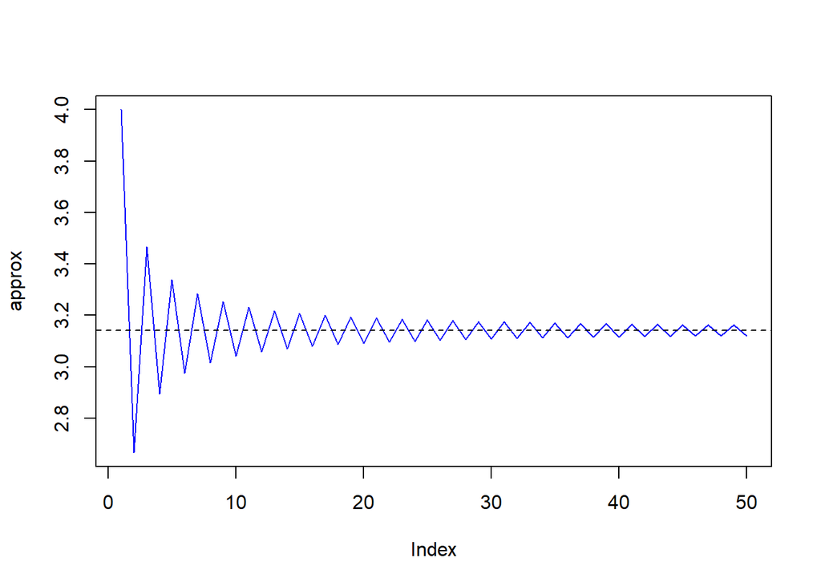

```
[1] 3.121595
```

```r
n <- 50
# ... Skipped code ...
plot(approx, type="l", col="blue")
abline(h=pi, lty=2)
tail(approx, 1)
```

**Solution:**

```r
n <- 100

approx <- numeric(n)
approx[1] <- 4
k <- 3
s <- -1 # Sign
for (i in 2:n) {
  approx[i] <- approx[i-1] + s * 4 / k
  k <- k + 2
  s <- -s
}
plot(approx, type="l", col="blue")
abline(h=pi, lty=2)
tail(approx, 1)
```

6. The [Monte Carlo method](https://en.wikipedia.org/wiki/Monte_Carlo_method) is a technique to approximate a quantity by first viewing it as (some function of) a probability value and then approximate the probability value by some long-run frequencies of random events. We can approximate $\pi$ as follows:
   - If $X$ and $Y$ are two independent variables distributed uniformly in the interval $[-1, 1]$, then the point $(X,Y)$ is distributed uniformly in the square $[-1,1]\times[-1,1]$.
   - The probability that such a random point $(X,Y)$ also lies inside the unit circle $\{(x,y): x^2 + y^2 < 1\}$ of radius $1$ is equals to the ratio of the area of the unit circle and the area of the square i.e. $\pi/4$. In other words,
     $$P(X^2 + Y^2 < 1) = \pi / 4$$
   - Suppose we generate a sequence $(x_1,y_1), (x_2, y_2), \dots, (x_n, y_n)$ of random points inside $[-1,1]\times[-1,1]$ and count the fraction of points that also lie inside the unit circle. Then this fraction should be close to $\pi/4$.
   - Mathematically, if we let $a_i = 1$ if $x_i^2 + y_i^2 < 1$ and let $a_i=0$ otherwise, then
     $$\pi/4 = P(X^2 + Y^2 < 1) \approx \frac{1}{n}\sum_{i=1}^n a_i$$
   - Write an R program that uses the above idea to approximate $\pi$. (Hint: Use `runif(1, -1, 1)` to generate a point randomly and uniformly in the interval $[-1,1]$.)

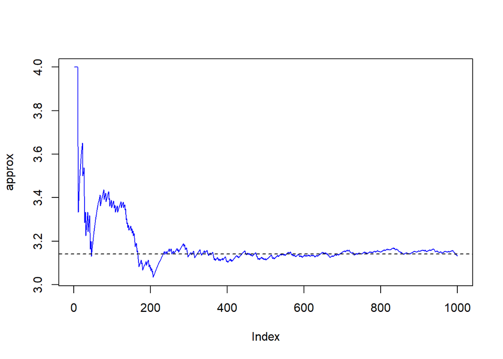

```
[1] 3.132
```

```r
n <- 1000
# ... Skipped code ...
plot(approx, type="l", col="blue")
abline(h=pi, lty=2)
tail(approx, 1)
```

**Solution:**

```r
n <- 1000

set.seed(3)
approx <- numeric(n)
num.success <- 0
for (i in 1:n) {
  x <- runif(1, -1, 1)
  y <- runif(1, -1, 1)
  if (x^2 + y^2 <= 1) {
    num.success <- num.success + 1
  }
  approx[i] <- num.success / i * 4
}
plot(approx, type="l", col="blue")
abline(h=pi, lty=2)
tail(approx, 1)
```

7. Write an R program that takes a vector `x` and checks if `x` has any duplicate element. Do not use any R’s built-in function such as `%in%()` or `is.element()`. (Hint: Use more than one `break`. The loop pattern in Lecture 2 Homework Question 1 might be useful.)

```r
x <- c(3, -7, 6, 3, 1, -7)
# ... Skipped code ...
answer
```

```
[1] TRUE
```

**Solution:**

```r
x <- c(3, -7, 6, 3, 1, -7)

n <- length(x)
answer <- FALSE
if (n > 1) {
  for (i in 2:n) {
    for (j in 1:(i-1)) {
      if (x[i] == x[j]) {
        answer <- TRUE
        break
      }
    }
    if (answer) {
      break
    }
  }
}
answer
```

8. Write an R program to mimic the built-in R function `unique()` which returns the set of distinct elements for a vector `x`.

```r
x <- c(3, -7, 6, 3, 1, -7)
# ... Skipped code ...
answer
```

```
[1]  3 -7  6  1
```

**Solution:**

```r
x <- c(3, -7, 6, 3, 1, -7)

answer <- c()
for (v in x) {
  found <- FALSE
  for (a in answer) {
    if (a == v) {
      found <- TRUE
      break
    }
  }
  if (!found) {
    answer <- c(answer, v)
  }
}
answer
```

9. Write an R program that takes a vector `x` of numbers and computes its mode i.e. (any of) the value that appears most often. (Hint: Do Exercise 8 first.)

```r
x <- c(8, -4, 10, 10, -4, 10)
# ... Skipped code ...
answer
```

```
[1] 10
```

**Solution:**

```r
x <- c(8, -4, 10, 10, -4, 10)

unique.x <- c()
counter <- c()
for (v in x) {
  found <- FALSE
  # Have we seen v before?
  for (i in seq_along(unique.x)) {
    if (v == unique.x[i]) {
      found <- TRUE
      counter[i] <- counter[i] + 1
      break
    }
  }
  if (!found) {
    unique.x <- c(unique.x, v)
    counter <- c(counter, 1)
  }
}
# Find the largest counter.
largest.idx <- 1
num.unique <- length(unique.x)
if (num.unique > 1) {
  for (i in 2:num.unique) {
    if (counter[i] > counter[largest.idx]) {
      largest.idx <- i
    }
  }
}
answer <- unique.x[largest.idx]
answer
```

10. [Bubble sort](https://en.wikipedia.org/wiki/Bubble_sort) is one of the simplest (and inefficient) algorithms to sort a sequence of numbers. Here is how the bubble sort works:
    - For example, suppose `x <- c(5, 2, 8, 1, 4)`.
    - In the 1st pass, our goal is to move the largest element $8$ to the last entry of `x`.
      - Start from the left and compare the first pair `x[1]` and `x[2]`. Since $5 > 2$, we swap them (in-place). Now `x` is `2, 5, 8, 1, 4`.
      - Next, we inspect the next pair `x[2]` and `x[3]`. Since $5 < 8$, they are in ascending order already. So we don’t swap them.
      - Moving on to the next pair `x[3]` and `x[4]`. Since $8 > 1$, we swap them. Now `x` is `2, 5, 1, 8, 4`.
      - Finally, we compare `x[4]` with `x[5]`. Since $8 > 4$, we swap them. Now `x` is `2, 5, 1, 4, 8`.
      - We have successfully identified the largest number and moved it to the last entry of `x` i.e. “bubbled it to the top”.
      - This completes the 1st pass.
    - In the 2nd pass, our goal is to move the 2nd largest element to the 2nd last entry of `x`.
      - Similar to the 1st pass, we start from the left and compare `x[1]` and `x[2]`. Since $2 < 5$, we don’t swap them.
      - Next, we inspect the next pair `x[2]` and `x[3]`. Since $5 > 1$, we swap them. Now `x` is `2, 1, 5, 4, 8`.
      - Finally, we compare `x[3]` and `x[4]`. Since $5 > 4$, we swap them. Now `x` is `2, 1, 4, 5, 8`.
      - This completes the 2nd pass.
    - In general, after each pass, we would have moved the $i^\text{th}$ largest number among `x[1:(n+1-i)]` to the entry `x[n+1-i]`.
    - Therefore, `x` will become sorted after $n-1$ passes. (Why is it $n-1$ but not $n$ passes?)
    - Now implement the above logic in an R program. Try to `print(x)` in your program after each pass.
    - When you run your program, you might notice that sometimes the sequence `x` becomes sorted before all $n-1$ passes. So the final few passes are not swapping anything. Indeed, if there is an intermediate pass that does not swap any two numbers, then `x` is sorted. So the program can exit early.
    - Now modify your program to incorporate this “early exit” logic.

```r
x <- c(59, 12, 67, 88, 72, 41, 26, 37, 75, 85)
# ... Skipped code with print(x) ...
```

```
 [1] 12 59 67 72 41 26 37 75 85 88
 [1] 12 59 67 41 26 37 72 75 85 88
 [1] 12 59 41 26 37 67 72 75 85 88
 [1] 12 41 26 37 59 67 72 75 85 88
 [1] 12 26 37 41 59 67 72 75 85 88
 [1] 12 26 37 41 59 67 72 75 85 88
```

**Solution:**

```r
x <- c(59, 12, 67, 88, 72, 41, 26, 37, 75, 85)

n <- length(x)
if (n > 1) {
  for (i in n:2) {
    swap <- FALSE
    for (j in 1:(i-1)) {
      if (x[j] > x[j+1]) {
        # Swap x[j] and x[j+1]
        temp <- x[j]
        x[j] <- x[j+1]
        x[j+1] <- temp
        swap <- TRUE
      }
    }
    print(x)
    # Exit early?
    if (!swap) {
      break
    }
  }
}
```

# 4 Lecture 4

## 4.1 Newton-Raphson Algorithm

**Introduction**

The [Newton-Raphson root-finding method](https://en.wikipedia.org/wiki/Newton's_method) is an iterative algorithm for find successively better approximations to the roots (or zeros) of a real-valued differentiable function. For example, if the function is $f(x) = x^2 - 4x - 7$, then it has two roots at $x^*=-1.317$ and $x^*=5.317$.

**The Algorithm**

1. Start at some arbitrary $x_0$.
2. For each $t=0,1,2,3,...$ iteration, compute the next $x_{t+1}$ using the following updating equation:
   $$x_{t+1} = x_t - \frac{f(x_t)}{f'(x_t)}$$
3. Repeat until either $t$ is large or if $|x_{t+1} - x_t| < \epsilon$ for some small tolerance $\epsilon > 0$.
4. At the end, we have $f(x_T) \approx 0$.

**Why Does It Work?**

The special case for a straight line function $f$. Draw a picture. In general, use linear approximation.

**Exercise 1**

In the following exercises, we will focus on the function $f(x) = x^2 -4x - 7$. Differentiate $f(x)$ analytically to obtain $f'(x)$. Write down the mathematical formula for the updating equation in step 2 of the algorithm.

**Solution:**

```r
x.new <- x.old - (x.old^2 - 4 * x.old - 7) / (2 * x.old - 4)
```

**Exercise 2**

Write a FOR loop to implement the algorithm with $T=100$ iterations. (Note that you can just hard-code the updating equation from Exercise 1 into your program.)

```r
num.iter <- 100
x0 <- 10
# ... Skipped code ...
root
```

```
[1] 5.316625
```

**Solution:**

```r
num.iter <- 100
x0 <- 10

x <- x0
for (t in 1:num.iter) {
  x <- x - (x^2 - 4 * x - 7) / (2 * x - 4)
  # Note that there is no need to keep track of all the x's.
  # It suffices store the updated value inside the same variable x in-place.
}
root <- x
```

**Exercise 3**

Write a WHILE loop to implement the algorithm with the exit condition of $|x_{t+1} - x_{t}| < \epsilon$ where $\epsilon = 10^{-10}$. (Hint: Use the `while (TRUE)` and `break` programming pattern.)

```r
epsilon <- 1e-10
x0 <- 10
# ... Skipped code ...
root
```

```
[1] 5.316625
```

**Solution:**

```r
epsilon <- 1e-10
x0 <- 10

x.old <- x0
while (TRUE) {
  x.new <- x.old - (x.old^2 - 4 * x.old - 7) / (2 * x.old - 4)
  if (abs(x.new - x.old) < epsilon) {
    break
  }
  x.old <- x.new
}
root <- x.new
```

**Exercise 4**

Modify the FOR loop in Exercise 2 to also incorporate the exit condition of Exercise 3 i.e. quit the iteration if either $|x_{t+1} - x_t| < 10^{-10}$ or the number of iterations reaches $T=100$

```r
num.iter <- 100
epsilon <- 1e-10
x0 <- 10
# ... Skipped code with a FOR loop ...
root
```

```
[1] 5.316625
```

**Solution:**

```r
num.iter <- 100
epsilon <- 1e-10
x0 <- 10

x <- x0
for (t in 1:num.iter) {
  update <- (x^2 - 4 * x - 7) / (2 * x - 4)
  if (abs(update) < epsilon) {
    break
  }
  x <- x - update
}
root <- x
```

**Exercise 5**

Modify the WHILE loop in Exercise 3 to also incorporate the exit condition of Exercise 2 i.e. quit the iteration if either $|x_{t+1} - x_t| < 10^{-10}$ or the number of iterations reaches $T=100$

```r
num.iter <- 100
epsilon <- 1e-10
x0 <- 10
# ... Skipped code ...
root
```

```
[1] 5.316625
```

**Solution:**

```r
num.iter <- 100
epsilon <- 1e-10
x0 <- 10

t <- 0 # Use a counter to keep track of the number of iterations so far.
x.old <- x0
while (TRUE) {
  t <- t + 1
  x.new <- x.old - (x.old^2 - 4 * x.old - 7) / (2 * x.old - 4)
  if (abs(x.new - x.old) < epsilon || t == num.iter) {
    break
  }
  x.old <- x.new
}
root <- x.new
```

# 5 Lecture 5

## 5.1 Function

- Use a function to encapsulate a block of code so that:
  - You have a functionality that is resuable and can be deployed at multiple places i.e. “write once, use anywhere”
  - You can break a lengthy piece of code into smaller and more managable logical components
  - It is easier to isolate, test, debug, and modify your code i.e. “change once, affect everywhere”
- The typical components of a function are:
  1. The keyword `function` and the parentheses `()`
  2. (Optional) One or more input arguments inside `()`
  3. A block of one or more lines of code inside `{}` i.e. the body
  4. (Optional) A return value and the keyword `return`
- A function needs to be defined first before it can be “called” i.e. used.

For example, here is a simple function that takes an input `x` and returns its squared value.

```r
# Define a function and stores it inside the object "squaring"
squaring <- function(x) {
  return(x * x)
}

# Use the functionality by calling "squaring"
squaring(3)
```

```
[1] 9
```

- A function can have no input argument.

```r
today.is.wednesday <- function() {
  return(weekdays(Sys.Date()) == "Wednesday")
}

today.is.wednesday()
```

```
[1] FALSE
```

- A function can have multiple input arguments.

```r
quadratic.root <- function(a, b, c) {
  # Solve f(x) = ax^2 + bx + c = 0 for x
  d <- b^2 - 4 * a * c
  return((-b + c(-sqrt(d), sqrt(d))) / (2 * a))
}

quadratic.root(2, -14, 24)
```

```
[1] 3 4
```

- A function can have no output.

```r
say.word <- function(word) {
  cat(word) # Show the word on the console directly
}

say.word("Hello")
```

```
Hello
```

- A function can have essentially multiple outputs by using the trick that returns a `list`.

```r
five.number.summary <- function(x) {
  m1 <- min(x)
  q1 <- quantile(x, 0.25, names=FALSE)
  q2 <- median(x)
  q3 <- quantile(x, 0.75, names=FALSE)
  m2 <- max(x)
  return(list(minimum=m1, first.quartile=q1, median=q2, third.quartile=q3,
              maximum=m2)) # Put all the stuff in a list and return the list
}

x <- c(0.6, 1.7, 0.4, -0.3, -0.3, 0.2, -0.2, -1.5, 1.6, 1.5)
(result <- five.number.summary(x))
```

```
$minimum
[1] -1.5

$first.quartile
[1] -0.275

$median
[1] 0.3

$third.quartile
[1] 1.275

$maximum
[1] 1.7
```

```r
result$first.quartile
```

```
[1] -0.275
```

- In R, the `return` keyword is optional. In this case, the value of the lastly evaluated expression is returned.

```r
squaring <- function(x) {
  x * x
}

squaring(3)
```

```
[1] 9
```

- If the `return` keyword is optional, then why would you ever want to use the `return` keyword explicitly? Answer: To exit the function early.

For example, here are two logically equivalent ways to implement the `any()` functionality.

```r
annie <- function(x) {
  answer <- FALSE
  for (value in x) {
    if (value) {
      answer <- TRUE
      break
    }
  }
  return(answer) # Only exit the function here
}
```

```r
annie <- function(x) {
  for (value in x) {
    if (value) {
      return(TRUE) # Can exit the function early
    }
  }
  return(FALSE)
}
```

- If you use `return()` without any value inside `()`, then it will return `NULL`.

**Exercise:** Write an R function that takes a number `score` between $0$ and $100$ as argument and returns a letter grade according to the following table

| Score | Letter Grade |
| --- | --- |
| 90 - 100 | A |
| 80 - 89 | B |
| 70 - 79 | C |
| 60 - 69 | D |
| 50 - 59 | E |
| 0 - 49 | F |

For example,

```r
grading <- function(score) {
  # ... Skipped code ...
}

(letter.grade <- grading(83))
```

**Solution:**

```r
grading <- function(score) {
  # Just borrow our previous code by copying and pasting the relevant part here.
  if (score >= 90) {
    letter.grade <- "A"
  } else if (score >= 80) {
    letter.grade <- "B"
  } else if (score >= 70) {
    letter.grade <- "C"
  } else if (score >= 60) {
    letter.grade <- "D"
  } else if (score >= 50) {
    letter.grade <- "E"
  } else {
    letter.grade <- "F"
  }
  return(letter.grade)
}

(letter.grade <- grading(83))
```

```
[1] "B"
```

- There are two simple ways to reuse functions that you have written before:
  1. Copy and paste the function code directly into the file of your current code.
  2. Save the function code in another file, and `source()` it in your current code.

## 5.2 Default, Named, and Missing Argument

- Default argument: A convenient feature in R that allows you to pre-assign a specific value to an argument of a function. The value is in effect unless the user who calls the function overwrites the value explicitly.
- Use default argument when a function has a commonly used case but you still want to keep it flexible enough for general usage.

For example, the $L_p$-norm of a vector $x=(x_1,\dotsc,x_d)$ is defined as
$$\left\lVert x \right\rVert_p = \left(\sum_{i=1}^d \left\lvert x_i \right\rvert ^p\right)^{1/p}$$

```r
vector.norm <- function(x, p=2) {
  return(sum(abs(x)^p)^(1/p))
}

x <- c(-1, 0, 2)

vector.norm(x) # No need to specify p.
vector.norm(x, 2)
vector.norm(x, 1)
vector.norm(x) # Note that p is not set to 1
```

```
[1] 2.236068
[1] 2.236068
[1] 3
[1] 2.236068
```

- Use default argument when you want to expand the functionality of an existing function beyonds its original intent while maintaining the old interface for backward compatibility.

```r
vector.norm <- function(x) { # Can only compute L2-norm.
  return(sqrt(sum(x^2)))
}

x <- c(-1, 0, 2)
vector.norm(x)

vector.norm <- function(x, p=2) { # Adding new functionality.
  return(sum(abs(x)^p)^(1/p))
}

vector.norm(x) # Same interface so the old function call stills work.
```

```
[1] 2.236068
[1] 2.236068
```

- Named argument: Allow you to specify the values of some specific arguments of a function more explicitly without relying on the position of the argument.

```r
f <- function(x, a=1, b=2) {
  return((x + a) * b)
}

f(10)
f(10, 3, 4)
f(10, a=3)
f(10, b=4)
```

```
[1] 22
[1] 52
[1] 26
[1] 44
```

- Since there is no ambiguity in which argument a named value should be matched with, you can put named arguments not in the original ordering that is specified by the function.
- Named argument matching rules:
  1. Match those arguments with complete names
  2. Match those arguments with partial but unambiguous names
  3. Match the unnamed arguments in sequential order

```r
f <- function(alice, andy, anna, bob) {
  return(c(alice, andy, anna, bob))
}

f(1, 2, 3, 4)
f(bob=1, andy=2, 3, 4)
f(1, b=2, al=3, 4)
# f(1, an=2, al=3, 4) # Error
```

```
[1] 1 2 3 4
[1] 3 2 4 1
[1] 3 1 4 2
```

- Built-in R functions: `match.arg()`, `missing()`
- How to read R’s documentation e.g. `?mean`, `?sample`, `?paste`

Below is a useful function to generate a password randomly given a set of character choices.

```r
random.password <- function(n, choice=c(letters, LETTERS)) { # See ?letters
  password <- paste(sample(choice, n, replace=TRUE), collapse="")
  return(password)
}

random.password(10)      # Use default argument
random.password(10, 0:9) # Use {0, ..., 9} instead of alphabets
```

```
[1] "dMaHwQnrYG"
[1] "4495968448"
```

- Missing argument: R would not complain about a missing argument if it is not being used (thanks to the [lazy evaluation](https://en.wikipedia.org/wiki/Lazy_evaluation) nature of R).

```r
f <- function(x, a=2, b) {
  if (a == 2) {
    return(x + a)
  } else {
    return((x + a) * b)
  }
}

f(10)
# f(10, a=3) # Error
f(10, a=3, b=4)
```

```
[1] 12
[1] 52
```